# Anticipatory Action Trigger Mechanism Report

Drought in Chad

Last updated: 2023-01-06

## Key Messages

- LIMITED HISTORICAL DATA

  Due to limited historical data, no performance metrics were calculated Triggers 1 and 2 and the likelihood of activation for these triggers was estimated based on all available forecasts across the globe, not just forecasts for Chad or the area of interest. This means that there is high uncertainty in the likelihood of activation, and limited understanding of performance for these predictive triggers.
- ACTIVATION

  There is a 17 - 25% chance that Trigger 3 will activate in a given year. The Trigger 1 or 2 thresholds are met in 11% of all historical forecasts globally, however there is high uncertainty on how frequently this would occur in Chad.
- SHOCK DETECTION

  Package 3 is expected to be implemented ahead of 50 - 71% of shocks.
- FALSE ALARMS

  The risk of activating Package 3 in the absence of a severe shock stands at 29 - 50% of activations.
- NO REGRETS BIAS

  The mechanism is optimised to reduce the risk of failing to activate when there is a shock, at the cost of having false alarms.

## About Metric Estimates

The estimates in this report are shown as ranges called confidence intervals. The confidence intervals reflect the probabilistic nature of the estimates as well as the impact of data limitations (small or incomplete datasets, errors or imprecision in measurements, divergences between data sources, etc.) on the accuracy of estimates. They can inform decision-making by illustrating the most likely performance levels and by providing bounds for the possible albeit unlikely extremes.

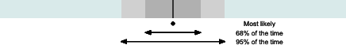

- The central value is the most likely performance;
- Most often the trigger will perform within the darker inner range (68% of the time);
- There is high confidence that the trigger will perform within the full coloured (grey or blue) range (95% of the time).

## Colour Coding

In the visualizations blue represents activation likelihood, green represents desired outcomes (valid non-activations/activations) and red represents undesired outcomes or errors.

## Trigger Mechanism Snapshot

This table summarises the trigger mechanism and its performance in signaling severe shocks. It presents estimates of the likelihood that the threshold would be met in a given year as well as how often the trigger is expected to correctly recommend an activation or non-activation.

Trigger 1

Trigger 2

Trigger 3

**Description**

Type

Predictive

Predictive

Observational

Monitored Area

Central Chad

Central Chad

Central Chad

Activation Timepoints

Mar, Apr

May, Jun

Sep

Target Period

Jul-Sep

Jul-Sep

Apr-Sep

Lead Time

4-3 months

2-1 months

N/A

Data Source

IRI tercile seasonal forecast

IRI tercile seasonal forecast

Biomass

Threshold

42.5% below average probability

42.5% below average probability

Seasonal anomaly below 80%

Historical Data Coverage

2018 - present

2018 - Present

2000 - Present

**Programming and Funding**

Monitored by

CHD

CHD

CHD

Activity Package

Package 1

Package 2

Package 3

Probability of being met in a given year

7%, based on global IRI data, but very high uncertainty

8%, based on global IRI data, but very high uncertainty

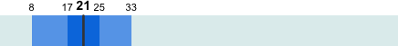

Funding Amount

$3.71m

$1.66m

$4.63m

Expected Annual Cost

$0.26m

$0.13m

$0.97m

**Performance**

All Activations (%)

N/A

N/A

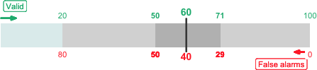

All Shocks (%)

N/A

N/A

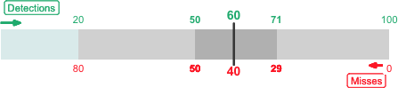

Notes

Expected annual cost computed using most likely probability of activation (central value). All triggers can reach their threshold and activate independently from one another. Triggers 1 and 2 did not have sufficient data for testing performance on Chad, but likelihood of activation was estimated based on all available global data, not just forecasts for Chad. The estimated likelihood of activation for these triggers is low, as thresholds were set based on IRI bins for reporting that require a high probability of below average precipitation. This ensures activation only when the forecast is quite certain of below average precipitation, and thus the low likelihood of activation. Trigger 3 performance was assessed by comparing recommended activations with historical bad years (i.e., years with a shock). ‘Bad years’ were identified through convergence of evidence reviewed from historical CERF allocations, FEWS NET reports, EM-DAT data, World Bank statistics and the 2015 and 2017 multi-risk contingency plans for Chad.

## Activation Scenarios

The IRI seasonal forecast over Chad has not reached the threshold in the historical data since 2018, when there were also no recorded droughts. While all available historical forecasts globally were used to calculate the individual likelihood of activation for Trigger 1 and 2, the observational Trigger 3 needs to be calculated over a specific area. Since we do not want to do that with the limited forecast data available, we do not estimate the joint likelihood of activation of the predictive and observational trigger together. Refer to the likelihood of the individual triggers activating.

## Technical Team

IRI Columbia University, the Food and Agriculture Organization (FAO), and Action Against Hunger (ACF) Spain have provided data and/or analytical support. A total of 5 historical occurrences of severe shocks were documented and used to develop the trigger mechanism, from 2001 to 2017. Only 5 years of historical forecasts were available, from 2018 onward, and none overlapped the historical shock data. Observational data was available from 2000 onward, covering all reported historical shocks. The triggers were developed by the Centre for Humanitarian Data close collaboration with OCHA, FAO, and other participating agencies.

## Monitoring Process

Between March and June inclusively, the Centre for Humanitarian Data will monitor IRI seasonal forecasts for Triggers 1 and 2. Seasonal forecasts are released on the 15th of each month, and if the 15th falls on a weekend, then it is released on the closest weekday. Within 24 hours of the update, the CHD team notifies the AA team, the Chad Humanitarian Coordinator, and the Chief of CERF by email whether or not the trigger is met. By September 1, updates to the Chad biomass data from ACF Spain should be published for the second dekad of August. Within 24 hours, the Centre for Humanitarian Data will calculate cumulative biomass, compare to the threshold, and report to the AA team, the Chad Humanitarian Coordinator, and the Chief of CERF if Trigger 3 has been met. In case of an activation, additional meteorological and agricultural data will be shared by the Centre for Humanitarian Data and/or FAO to inform response targeting.

## Learning Opportunities

This table summarises the decisions, assumptions, and open questions that arose during trigger development. They are documented for transparency and to inform the learning agenda.

[output not shown]